# Product Proliferation, Complexity, and Deterrence

Michele Piazzai and Nachoem M. Wijnberg

Strategic Management Journal, 2019

Load the packages needed to run the code below.

```r
library(combinat)
library(data.table)
library(doParallel)
library(dplyr)
library(foreach)
library(ggplot2)
library(Hmisc)
library(MASS)
library(perturb)
library(reshape2)
library(rjson)
library(rvest)
library(stringr)
library(qlcMatrix)

options(scipen = 3)
```

## Prepare data

After extracting the tarball with raw data, load it and keep only data about releases from 2004 onward.

```r
clust <- detectCores() - 1

single <-
  read.csv("single.csv", stringsAsFactors = F)[, -1] %>% data.table()
billboard <-
  read.csv("billboard.csv", stringsAsFactors = F)[, -1] %>% data.table()
fuzzy <-
  read.csv("fuzzy.csv", stringsAsFactors = F)[, -1] %>% data.table()
label <-
  read.csv("label.csv", stringsAsFactors = F) %>% data.table()
parent <-
  read.csv("parent.csv", stringsAsFactors = F) %>% data.table()
hierarchy <-
  read.csv("hierarchy.csv", stringsAsFactors = F)[,-1] %>% data.table()
mahala <-
  read.csv("mahala.csv", stringsAsFactors = F) %>% data.table()

label <- label[rYear > 2003]

parent <- parent[(kEnd > 2003 | is.na(kEnd)) & kId == 200]
parent[is.na(parent$kStart)]$kStart <- 0
parent[is.na(parent$kEnd)]$kEnd <- 9999

single$mStyle2 <-
  gsub(",", ">,<", paste('<', (single$mStyle), '>', sep = ""))
```

## Link singles to majors

Run a recursive search through the `parent` table in order to link each release to one of the majors or flag it as an independent release.

```r
FindTopParent <- function (x, y) {
  if (is.na(x)) {
    return("self")
  }
  child <- x
  repeat {
    if (nrow(parent[cId == x & kStart <= y & kEnd >= y]) == 0) {
      return("indie")
    }
    owner <- min(parent[cId == child & kStart <= y & kEnd >= y]$pId)
    if (nrow(parent[cId == owner & kStart <= y & kEnd >= y]) == 0) {
      break
    }
    child <- owner
  }
  top <- unique(parent[pId == owner]$pName)
  ifelse(grepl("Sony", top),
         "sony",
         ifelse(
           grepl("Universal", top),
           "universal",
           ifelse(
             grepl("Warner", top),
             "warner",
             ifelse(grepl("EMI", top), "emi", "indie")
           )
         ))
}

label$lParent <- mapply(FindTopParent, label$lDiscogs, label$rYear)
```

## Wide format setup

Put the data in wide format, where each line is a major-style-year triple. Drop the EMI observations later than 2011 because at the end of this year EMI disbanded.

```r
majors <- c("sony", "universal", "warner", "emi")
years <- 2004:2014
genres <- unique(unlist(strsplit(data.matrix(single$mGenre), ",")))
styles <- unique(unlist(strsplit(data.matrix(single$mStyle), ",")))

styles <- styles[-which(styles == "shoegazer")]

yearly <-
  expand.grid("major" = majors,
              "year" = years,
              "style" = styles) %>% data.table()

yearly <- yearly[!(major == "emi" & year > 2011) & year > 2004]

lag <- 1
```

## Root genre

For each style, find the root genre (e.g., `rock` is the root of `punk-rock`).

```r
FindRootGenre <- function (x) {
  as.character(hierarchy[child == x]$root)
}

yearly$genre <- mcmapply(FindRootGenre, yearly$style, mc.cores = clust)
```

## Yearly releases

Count the total number of single released by a major in a style-year. Then count the total number of singles released by *rival* majors in the style-year, and the total number of singles released by independents.

```r
CountOwnSingles <- function (x, y, z) {
  z <- paste("<", z, ">", sep = "")
  inYear <- label[lParent == x & rYear == y]$mId
  inStyle <- single[mId %in% inYear & grepl(z, mStyle2)]
  nrow(inStyle)
}

yearly$ownSingles <-
  mcmapply(CountOwnSingles,
           yearly$major,
           yearly$year,
           yearly$style,
           mc.cores = clust)
```

```r
ComputeRivalSingles <- function (x, y, z) {
  z <- paste("<", z, ">", sep = "")
  inYear <-
    label[lParent != x &
            lParent != "indie" & lParent != "self" & rYear == y]$mId
  inStyle <- single[mId %in% inYear & grepl(z, mStyle2)]$mId
  rivals <- majors[-which(majors == x)]
  if (y > 2011) {
    rivals <- rivals[-which(rivals == "emi")]
  }
  total <- 0
  for (i in rivals) {
    total <- c(total, nrow(label[mId %in% inStyle & lParent == i]))
  }
  sum(total)
}

yearly$rivalSingles <-
  mcmapply(ComputeRivalSingles,
           yearly$major,
           yearly$year - lag,
           yearly$style,
           mc.cores = clust)
```

```r
CountIndieSingles <- function (x, y, z) {
  z <- paste("<", z, ">", sep = "")
  inYear <- label[lParent == "indie" & rYear == y]$mId
  inStyle <- single[mId %in% inYear & grepl(z, mStyle2)]
  nrow(inStyle)
}

yearly$indieSingles <-
  mcmapply(CountIndieSingles,
           yearly$major,
           yearly$year - lag,
           yearly$style,
           mc.cores = clust)
```

## Lagged dependent

Lag the total number of singles released by the major in the style-year.

```r
yearly$ownSinglesLag <-
  mcmapply(CountOwnSingles,
           yearly$major,
           yearly$year - lag,
           yearly$style,
           mc.cores = clust)
```

## Portfolio Size

Compute the total number of singles released by the major during the year, regardless of style.

```r
CountOwnTotal <- function(x, y) {
  inYear <- label[lParent == x & rYear == y]
  nrow(inYear)
}

yearly$ownTotal <-
  mcmapply(CountOwnTotal, yearly$major, yearly$year - lag, mc.cores = clust)
```

## Billboard success

Calculate the number of Billboard entries for a major in a style-year as a measure of competitive performance.

```r
MeasureBillboardRanks <- function (x, y, z) {
  z <- paste("<", z, ">", sep = "")
  inYear <- label[lParent == x & rYear == y]$mId
  inStyle <- single[mId %in% inYear & grepl(z, mStyle2)]$mId
  ranks <- billboard[fuzzy10 %in% inStyle & bYear == y]$bRank
  sum((101 - ranks) / 100)
}

yearly$billboard <-
  mcmapply(MeasureBillboardRanks,
           yearly$major,
           yearly$year - lag,
           yearly$style,
           mc.cores = clust)
```

## Diversification

Compute a Herfindahl-Hirschman index to measure the diversification of majors across styles in a year.

```r
ComputeHerfindahl <- function (x, y) {
  inYear <- label[lParent == x & rYear == y]$mId
  byStyle <-
    table(unlist(strsplit(data.matrix(single[mId %in% inYear]$mStyle), ",")))
  if (sum(byStyle) == 0) {
    return(0)
  }
  index <- 0
  for (i in 1:length(byStyle)) {
    index <- index + (byStyle[i] / sum(byStyle)) ^ 2
  }
  index
}

yearly$herfindahl <-
  mcmapply(ComputeHerfindahl, yearly$major, yearly$year - lag, mc.cores = clust)
```

## Demand

Compute the total number of Billboard entries belonging to a particular style in a year, regardless of record company, as a measure of demand for the style.

```r
ComputeDemand <- function (y, z) {
  z <- paste("<", z, ">", sep = "")
  inStyle <- single[grepl(z, mStyle2)]$mId
  ranks <- billboard[fuzzy10 %in% inStyle & bYear == y]$bRank
  sum((101 - ranks) / 100)
}

yearly$demand <-
  mcmapply(ComputeDemand, yearly$year - lag, yearly$style, mc.cores = clust)
```

## Complexity

Compute the level of product space complexity using acoustic features and Mahalanobis distances. If complexity cannot be computed for a style-year (e.g., because no records have been released), then the last known value of complexity for that style carries over to that year.

```r
features <- colnames(single)[5:33]

prototype <-
  expand.grid("style" = styles, "year" = years) %>% data.table()

prototype[, features] <- NA

ComputeMeanFeature <- function (x, y, z) {
  x <- paste("<", x, ">", sep = "")
  ifelse(nrow(single[grepl(x, mStyle2) & mYear == y]) == 0,
         NA, ifelse(sum(!is.na(single[grepl(x, mStyle2) &
                                        mYear == y][[z]])) == 0,
                    NA, mean(single[grepl(x, mStyle2) &
                                      mYear == y][[z]], na.rm = T)))
}

for (i in 3:31) {
  prototype[[i]] <-
    mcmapply(ComputeMeanFeature,
             prototype$style,
             prototype$year,
             i + 2,
             mc.cores = clust)
}
```

```r
cl <- makeCluster(clust)
registerDoParallel(cl)

distance <-
  data.table("single" = character(),
             "prototype" = character(),
             "year" = integer())

distance <-
  foreach(i = 1:nrow(single), .combine = "rbind") %dopar% {
    a <- single[i, "mId"]
    y <- single[i, "mYear"]
    b <- unlist(strsplit(single[i, "mStyle"], ","))
    expand.grid("single" = a, "prototype" = b, "year" = y)
  } %>% data.table() %>% droplevels()

stopCluster(cl)
rm(cl)
```

```r
covariance <-
  cov(single[complete.cases(single), 5:33])

ComputeMahalanobis <- function (x, y, z) {
  a <- single[as.matrix(single)[, 1] == x, 5:33]
  b <-
    prototype[as.matrix(prototype)[, 1] == y &
                as.matrix(prototype)[, 2] == z, 3:31]
  if (sum(is.na(a)) > 0 | sum(is.na(b)) > 0) {
    return(NA)
  }
  mahalanobis(as.matrix(a), as.matrix(b), covariance)
}

distance$mahala <-
  mcmapply(ComputeMahalanobis,
           distance$single,
           distance$prototype,
           distance$year,
           mc.cores = clust)

distance$prototype <- as.character(distance$prototype)
```

```r
ComputeComplexity <- function (x, y) {
  z <- paste("<", x, ">", sep = "")
  inStyle <- single[grepl(z, mStyle2) & mYear == y]$mId
  sqrtdist <-
    sqrt(distance[single %in% inStyle & prototype == x]$mahala)
  if (length(sqrtdist) == 0 | sum(!is.na(sqrtdist)) == 0) {
    return(NA)
  }
  mean(sqrtdist, na.rm = T)
}

yearly$complex <-
  mcmapply(ComputeComplexity,
           yearly$style,
           yearly$year - lag,
           mc.cores = clust)
```

```r
CarryComplexity <- function (x, y) {
  current <- unique(yearly[style == x & year == y]$complex)
  if (is.na(current)) {
    i <- 0
    repeat {
      i <- i + 1
      if (nrow(yearly[style == x & year == y - i]) == 0)
        break
      current <- unique(yearly[style == x & year == y - i]$complex)
      if (!is.na(current))
        break
    }
  }
  current
}

yearly$complex2 <-
  mcmapply(CarryComplexity,
           yearly$style,
           yearly$year,
           mc.cores = clust)
```

## Proliferation

Compute the level of rival product proliferation.

```r
ComputeProliferation <- function (x, y, z) {
  z <- paste("<", z, ">", sep = "")
  inYear <-
    label[lParent != x &
            lParent != "indie" & lParent != "self" & rYear == y]$mId
  inStyle <- single[mId %in% inYear & grepl(z, mStyle2)]$mId
  rivals <- majors[-which(majors == x)]
  if (y > 2011) {
    rivals <- rivals[-which(rivals == "emi")]
  }
  total <- 0
  for (i in rivals) {
    total <- c(total, nrow(label[mId %in% inStyle & lParent == i]))
  }
  max(total)
}

yearly$prolif <-
  mcmapply(ComputeProliferation,
           yearly$major,
           yearly$year - lag,
           yearly$style,
           mc.cores = clust)

yearly$rivalSingles2 <- yearly$rivalSingles - yearly$prolif
```

## Final sample

Put together the sample used for regression analysis. This is the `data.csv’ file.

```r
sample <-
  data.table(
    "Major" = yearly$major,
    "Style" = yearly$style,
    "Year" = yearly$year,
    "Genre" = yearly$genre,
    "OwnSingles" = yearly$ownSingles,
    "OwnSinglesLagged" = yearly$ownSinglesLag,
    "PortfolioSize" = yearly$ownTotal,
    "Performance" = yearly$billboard,
    "Diversification" = yearly$herfindahl,
    "Demand" = yearly$demand,
    "IndieSingles" = yearly$indieSingles,
    "MajorSingles" = yearly$rivalSingles2,
    "Proliferation" = yearly$prolif,
    "Complexity" = yearly$complex2
  )

iv <-
  c(
    "OwnSinglesLagged",
    "PortfolioSize",
    "Performance",
    "Diversification",
    "Demand",
    "IndieSingles",
    "MajorSingles",
    "Proliferation",
    "Complexity"
  )

dv <- c("OwnSingles")

ctrl <- c("Major", "Year", "Style", "Genre")

noctrl <- c(dv, iv)
vars <- c(dv, ctrl, iv)

sample.unstd <- sample[complete.cases(sample[, ..vars]), ..vars]
sample.mean <- cbind(sample.unstd[, ..dv], sample.unstd[, ..ctrl], scale(sample.unstd[, ..iv], scale = F))
sample.std <- cbind(sample.unstd[, ..dv], sample.unstd[, ..ctrl], scale(sample.unstd[, ..iv]))
```

## Descriptive statistics

Compute correlations and various descriptives among regression variables, including the condition number to check collinearity.

```r
ComputeCorrelations <- function(x) {
  require(Hmisc)
  x <- as.matrix(x)
  R <- rcorr(x)$r
  p <- rcorr(x)$P

  mystars <- ifelse(p < .001, "***", ifelse(p < .01, "** ", ifelse(p < .05, "* ", " ")))

  R <- format(round(cbind(rep(-1.11, ncol(x)), R), 2))[,-1]

  Rnew <- matrix(paste(R, mystars, sep=""), ncol=ncol(x))
  diag(Rnew) <- paste(diag(R), " ", sep="")
  rownames(Rnew) <- colnames(x)
  colnames(Rnew) <- paste(colnames(x), "", sep="")

  Rnew <- as.matrix(Rnew)
  Rnew[upper.tri(Rnew, diag = TRUE)] <- ""
  Rnew <- as.data.frame(Rnew)

  Rnew <- cbind(Rnew[1:length(Rnew)-1])

  P <- format(round(cbind(rep(-1.11, ncol(x)), p), 3))[,-1]

  Pnew <- matrix(P, ncol=ncol(x))
  diag(Pnew) <- paste(diag(P), " ", sep="")
  rownames(Pnew) <- colnames(x)
  colnames(Pnew) <- paste(colnames(x), "", sep="")

  Pnew <- as.matrix(Pnew)
  Pnew[upper.tri(Pnew, diag = TRUE)] <- ""
  Pnew <- as.data.frame(Pnew)

  Pnew <- cbind(Pnew[1:length(Pnew)-1])

  return(list(Rnew, Pnew))
}
```

```r
cond.unstd <- colldiag(sample.unstd[, ..iv])
cond.mean <- colldiag(sample.mean[, ..iv])

descr <-
  data.table(
    "mean" = round(as.numeric(lapply(
      sample.unstd[, ..noctrl], mean, na.rm = T
    )), 2),
    "sd" = round(as.numeric(lapply(
      sample.unstd[, ..noctrl], sd, na.rm = T
    )), 2),
    "min" = round(as.numeric(lapply(
      sample.unstd[, ..noctrl], min, na.rm = T
    )), 2),
    "max" = round(as.numeric(lapply(
      sample.unstd[, ..noctrl], max, na.rm = T
    )), 2)
  )

corr.r <- ComputeCorrelations(sample.unstd[, ..noctrl])[[1]]
corr.p <- ComputeCorrelations(sample.unstd[, ..noctrl])[[2]]
```

```r
cond.unstd
```

```
## $condindx
##    cond.index
## 1    1.000000
## 2    1.455421
## 3    2.068663
## 4    2.906016
## 5    3.110969
## 6    3.236864
## 7    3.731631
## 8    4.199593
## 9    4.327692
## 10   6.121409
##
## $pi
##          intercept OwnSinglesLagged PortfolioSize  Performance
```

[output cut: 35 more lines]

```r
cond.mean
```

```
## $condindx
##    cond.index
## 1    1.000000
## 2    1.690441
## 3    1.857601
## 4    1.913292
## 5    2.025812
## 6    2.239877
## 7    2.724396
## 8    3.259434
## 9    3.609775
## 10   3.773643
##
## $pi
##          intercept OwnSinglesLagged PortfolioSize  Performance
```

[output cut: 35 more lines]

```r
descr
```

```
##     mean    sd min    max
## 1   0.10  0.50   0  10.00
## 2   0.10  0.51   0  10.00
## 3  10.76  7.95   0  35.00
## 4   0.36  3.41   0  88.08
## 5   0.14  0.13   0   1.00
## 6   5.03 20.17   0 203.39
## 7   1.05  2.82   0  32.00
## 8   0.08  0.49   0   8.00
## 9   0.26  0.88   0  11.00
## 10  2.01  2.20   0  11.15
```

```r
corr.r
```

```
##                  OwnSingles OwnSinglesLagged PortfolioSize Performance
## OwnSingles
## OwnSinglesLagged    0.61***
## PortfolioSize       0.12***          0.14***
## Performance         0.38***          0.60***       0.07***
## Diversification      -0.01          -0.04***      -0.24***      -0.01
## Demand              0.45***          0.52***        0.03*      0.50***
## IndieSingles        0.47***          0.50***       0.04**      0.30***
## MajorSingles        0.41***          0.39***         0.01      0.20***
## Proliferation       0.42***          0.44***         0.00      0.25***
## Complexity          0.22***          0.22***       0.06***     0.12***
##                  Diversification   Demand IndieSingles MajorSingles
## OwnSingles
## OwnSinglesLagged
## PortfolioSize
## Performance
## Diversification
## Demand                    -0.02
## IndieSingles               0.00   0.51***
## MajorSingles              -0.01   0.59***      0.62***
## Proliferation              0.00   0.66***      0.62***      0.71***
## Complexity                 0.02   0.28***      0.39***      0.20***
##                  Proliferation
## OwnSingles
## OwnSinglesLagged
## PortfolioSize
## Performance
## Diversification
## Demand
## IndieSingles
## MajorSingles
## Proliferation
## Complexity             0.31***
```

```r
corr.p
```

```
##                  OwnSingles OwnSinglesLagged PortfolioSize Performance
## OwnSingles
## OwnSinglesLagged      0.000
## PortfolioSize         0.000            0.000
## Performance           0.000            0.000         0.000
## Diversification       0.356            0.001         0.000       0.303
## Demand                0.000            0.000         0.020       0.000
## IndieSingles          0.000            0.000         0.002       0.000
## MajorSingles          0.000            0.000         0.595       0.000
## Proliferation         0.000            0.000         0.914       0.000
## Complexity            0.000            0.000         0.000       0.000
##                  Diversification Demand IndieSingles MajorSingles
## OwnSingles
## OwnSinglesLagged
## PortfolioSize
## Performance
## Diversification
## Demand                     0.204
## IndieSingles               0.828  0.000
## MajorSingles               0.549  0.000        0.000
## Proliferation              0.989  0.000        0.000        0.000
## Complexity                 0.069  0.000        0.000        0.000
##                  Proliferation
## OwnSingles
## OwnSinglesLagged
## PortfolioSize
## Performance
## Diversification
## Demand
## IndieSingles
## MajorSingles
## Proliferation
## Complexity               0.000
```

## Hierarchical regression

Estimate a null model and a control-only model.

```r
fit0 <- glm(OwnSingles ~ 1, family = "quasipoisson", data = sample.std)

model1 <-
  OwnSingles ~ factor(Major) + factor(Year) + factor(Genre) +
  OwnSinglesLagged + PortfolioSize + Performance + Diversification +
  Demand + IndieSingles + MajorSingles
fit1 <- glm(model1, family = "quasipoisson", data = sample.std)
```

```r
summary(fit1)
```

```
##
## Call:
## glm(formula = model1, family = "quasipoisson", data = sample.std)
##
## Deviance Residuals:
##     Min       1Q   Median       3Q      Max
## -3.5940  -0.3848  -0.2397  -0.1570   4.3581
##
## Coefficients:
##                                   Estimate Std. Error t value Pr(>|t|)
## (Intercept)                      -17.43896  640.62143  -0.027  0.97828
## factor(Major)universal             1.93167    0.25657   7.529 5.87e-14 ***
## factor(Major)warner                0.18287    0.15163   1.206  0.22787
## factor(Major)emi                   0.58984    0.15104   3.905 9.52e-05 ***
## factor(Year)2006                   0.34958    0.18573   1.882  0.05986 .
## factor(Year)2007                  -0.53973    0.18667  -2.891  0.00385 **
## factor(Year)2008                  -0.07222    0.18724  -0.386  0.69974
## factor(Year)2009                  -1.29333    0.20556  -6.292 3.36e-10 ***
## factor(Year)2010                  -1.41751    0.19489  -7.273 3.95e-13 ***
## factor(Year)2011                  -1.18446    0.18010  -6.577 5.22e-11 ***
## factor(Year)2012                  -1.45614    0.22836  -6.377 1.95e-10 ***
## factor(Year)2013                  -1.79779    0.26188  -6.865 7.32e-12 ***
## factor(Year)2014                  -3.82636    0.58421  -6.550 6.25e-11 ***
## factor(Genre)childrens             0.09809 1318.57583   0.000  0.99994
## factor(Genre)classical            -0.28108  876.52838   0.000  0.99974
## factor(Genre)electronic           14.73372  640.62140   0.023  0.98165
## factor(Genre)folk-world-country   14.20195  640.62165   0.022  0.98231
## factor(Genre)funk-soul            14.05586  640.62149   0.022  0.98250
## factor(Genre)hip-hop              15.06925  640.62141   0.024  0.98123
## factor(Genre)jazz                 12.42106  640.62214   0.019  0.98453
## factor(Genre)latin                13.07858  640.62214   0.020  0.98371
## factor(Genre)non-music            -0.43726  895.01827   0.000  0.99961
## factor(Genre)pop                  15.16585  640.62143   0.024  0.98111
## factor(Genre)reggae               13.52330  640.62165   0.021  0.98316
## factor(Genre)rock                 14.76409  640.62140   0.023  0.98161
## factor(Genre)stage-screen         -0.11492 1083.05424   0.000  0.99992
## OwnSinglesLagged                   0.16053    0.01488  10.785  < 2e-16 ***
## PortfolioSize                     -0.44145    0.09544  -4.625 3.82e-06 ***
## Performance                       -0.05267    0.01286  -4.095 4.27e-05 ***
## Diversification                    0.02169    0.04363   0.497  0.61914
## Demand                             0.21009    0.02060  10.196  < 2e-16 ***
## IndieSingles                       0.25009    0.02566   9.745  < 2e-16 ***
## MajorSingles                       0.01359    0.02167   0.627  0.53072
## ---
## Signif. codes:  0 '***' 0.001 '**' 0.01 '*' 0.05 '.' 0.1 ' ' 1
##
## (Dispersion parameter for quasipoisson family taken to be 0.9470238)
##
##     Null deviance: 3631.8  on 6068  degrees of freedom
## Residual deviance: 1921.0  on 6036  degrees of freedom
## AIC: NA
##
## Number of Fisher Scoring iterations: 16
```

```r
anova(fit0, fit1, test = "Chisq")
```

```
## Analysis of Deviance Table
##
## Model 1: OwnSingles ~ 1
## Model 2: OwnSingles ~ factor(Major) + factor(Year) + factor(Genre) + OwnSinglesLagged +
##     PortfolioSize + Performance + Diversification + Demand +
##     IndieSingles + MajorSingles
##   Resid. Df Resid. Dev Df Deviance  Pr(>Chi)
## 1      6068     3631.8
## 2      6036     1921.0 32   1710.8 < 2.2e-16 ***
## ---
## Signif. codes:  0 '***' 0.001 '**' 0.01 '*' 0.05 '.' 0.1 ' ' 1
```

```r
max(influence.measures(fit1)$infmat[, "cook.d"])
```

```
## [1] 1.972429
```

Estimate a model with the `Proliferation` variable.

```r
model2 <-
  OwnSingles ~ factor(Major) + factor(Year) + factor(Genre) +
  OwnSinglesLagged + PortfolioSize + Performance + Diversification +
  Demand + IndieSingles + MajorSingles + Proliferation
fit2 <- glm(model2, family = "quasipoisson", data = sample.std)
```

```r
summary(fit2)
```

```
##
## Call:
## glm(formula = model2, family = "quasipoisson", data = sample.std)
##
## Deviance Residuals:
##     Min       1Q   Median       3Q      Max
## -3.4932  -0.3768  -0.2359  -0.1576   4.4574
##
## Coefficients:
##                                   Estimate Std. Error t value Pr(>|t|)
## (Intercept)                      -17.48893  634.18059  -0.028 0.978000
## factor(Major)universal             2.01735    0.25477   7.918 2.84e-15 ***
## factor(Major)warner                0.19830    0.15048   1.318 0.187626
## factor(Major)emi                   0.57439    0.15022   3.824 0.000133 ***
## factor(Year)2006                   0.35927    0.18346   1.958 0.050238 .
## factor(Year)2007                  -0.67283    0.18970  -3.547 0.000393 ***
## factor(Year)2008                  -0.11393    0.18533  -0.615 0.538734
## factor(Year)2009                  -1.15272    0.20239  -5.695 1.29e-08 ***
## factor(Year)2010                  -1.31087    0.19276  -6.801 1.14e-11 ***
## factor(Year)2011                  -1.22893    0.17959  -6.843 8.52e-12 ***
## factor(Year)2012                  -1.50081    0.22729  -6.603 4.37e-11 ***
## factor(Year)2013                  -1.77707    0.25998  -6.835 8.98e-12 ***
## factor(Year)2014                  -3.79513    0.57966  -6.547 6.35e-11 ***
## factor(Genre)childrens             0.09066 1301.72563   0.000 0.999944
## factor(Genre)classical            -0.25988  868.28883   0.000 0.999761
## factor(Genre)electronic           14.74233  634.18056   0.023 0.981455
## factor(Genre)folk-world-country   14.23275  634.18080   0.022 0.982096
## factor(Genre)funk-soul            14.08394  634.18065   0.022 0.982283
## factor(Genre)hip-hop              14.89661  634.18057   0.023 0.981261
## factor(Genre)jazz                 12.44204  634.18129   0.020 0.984348
## factor(Genre)latin                13.11327  634.18129   0.021 0.983504
## factor(Genre)non-music            -0.40499  887.16359   0.000 0.999636
## factor(Genre)pop                  15.16176  634.18059   0.024 0.980927
## factor(Genre)reggae               13.54505  634.18080   0.021 0.982961
## factor(Genre)rock                 14.74015  634.18056   0.023 0.981457
## factor(Genre)stage-screen         -0.08326 1075.07372   0.000 0.999938
## OwnSinglesLagged                   0.15864    0.01464  10.836  < 2e-16 ***
## PortfolioSize                     -0.42516    0.09380  -4.533 5.93e-06 ***
## Performance                       -0.04350    0.01261  -3.451 0.000563 ***
## Diversification                    0.03490    0.04291   0.813 0.416114
## Demand                             0.18167    0.02086   8.707  < 2e-16 ***
## IndieSingles                       0.19792    0.02635   7.511 6.71e-14 ***
## MajorSingles                      -0.02584    0.02198  -1.176 0.239817
## Proliferation                      0.15918    0.02461   6.469 1.06e-10 ***
## ---
## Signif. codes:  0 '***' 0.001 '**' 0.01 '*' 0.05 '.' 0.1 ' ' 1
##
## (Dispersion parameter for quasipoisson family taken to be 0.9318989)
##
##     Null deviance: 3631.8  on 6068  degrees of freedom
## Residual deviance: 1886.3  on 6035  degrees of freedom
## AIC: NA
##
## Number of Fisher Scoring iterations: 16
```

```r
anova(fit1, fit2, test = "Chisq")
```

```
## Analysis of Deviance Table
##
## Model 1: OwnSingles ~ factor(Major) + factor(Year) + factor(Genre) + OwnSinglesLagged +
##     PortfolioSize + Performance + Diversification + Demand +
##     IndieSingles + MajorSingles
## Model 2: OwnSingles ~ factor(Major) + factor(Year) + factor(Genre) + OwnSinglesLagged +
##     PortfolioSize + Performance + Diversification + Demand +
##     IndieSingles + MajorSingles + Proliferation
##   Resid. Df Resid. Dev Df Deviance  Pr(>Chi)
## 1      6036     1921.0
## 2      6035     1886.3  1   34.725 1.032e-09 ***
## ---
## Signif. codes:  0 '***' 0.001 '**' 0.01 '*' 0.05 '.' 0.1 ' ' 1
```

```r
max(influence.measures(fit2)$infmat[, "cook.d"])
```

```
## [1] 1.506269
```

Estimate a model with the `Complexity` variable.

```r
model3 <-
  OwnSingles ~ factor(Major) + factor(Year) + factor(Genre) +
  OwnSinglesLagged + PortfolioSize + Performance + Diversification +
  Demand + IndieSingles + MajorSingles + Proliferation + Complexity
fit3 <- glm(model3, family = "quasipoisson", data = sample.std)
```

```r
summary(fit3)
```

```
##
## Call:
## glm(formula = model3, family = "quasipoisson", data = sample.std)
##
## Deviance Residuals:
##     Min       1Q   Median       3Q      Max
## -3.3011  -0.3347  -0.2026  -0.1111   4.2128
##
## Coefficients:
##                                   Estimate Std. Error t value Pr(>|t|)
## (Intercept)                     -1.759e+01  6.371e+02  -0.028  0.97798
## factor(Major)universal           1.961e+00  2.607e-01   7.523 6.15e-14 ***
## factor(Major)warner              1.868e-01  1.549e-01   1.206  0.22786
## factor(Major)emi                 6.111e-01  1.542e-01   3.963 7.49e-05 ***
## factor(Year)2006                 3.695e-01  1.886e-01   1.960  0.05009 .
## factor(Year)2007                -5.050e-01  1.945e-01  -2.596  0.00946 **
## factor(Year)2008                 2.816e-04  1.907e-01   0.001  0.99882
## factor(Year)2009                -9.040e-01  2.067e-01  -4.372 1.25e-05 ***
## factor(Year)2010                -9.773e-01  1.962e-01  -4.982 6.47e-07 ***
## factor(Year)2011                -9.825e-01  1.832e-01  -5.363 8.50e-08 ***
## factor(Year)2012                -1.276e+00  2.353e-01  -5.425 6.01e-08 ***
## factor(Year)2013                -1.405e+00  2.691e-01  -5.220 1.85e-07 ***
## factor(Year)2014                -3.291e+00  5.980e-01  -5.503 3.88e-08 ***
## factor(Genre)childrens           5.428e-01  1.343e+03   0.000  0.99968
## factor(Genre)classical           2.653e-01  8.948e+02   0.000  0.99976
## factor(Genre)electronic          1.422e+01  6.371e+02   0.022  0.98220
## factor(Genre)folk-world-country  1.444e+01  6.371e+02   0.023  0.98192
## factor(Genre)funk-soul           1.380e+01  6.371e+02   0.022  0.98271
## factor(Genre)hip-hop             1.440e+01  6.371e+02   0.023  0.98196
## factor(Genre)jazz                1.286e+01  6.371e+02   0.020  0.98390
## factor(Genre)latin               1.347e+01  6.371e+02   0.021  0.98313
## factor(Genre)non-music          -2.708e-01  9.114e+02   0.000  0.99976
## factor(Genre)pop                 1.446e+01  6.371e+02   0.023  0.98190
## factor(Genre)reggae              1.350e+01  6.371e+02   0.021  0.98310
## factor(Genre)rock                1.427e+01  6.371e+02   0.022  0.98213
## factor(Genre)stage-screen        4.043e-01  1.109e+03   0.000  0.99971
## OwnSinglesLagged                 1.451e-01  1.512e-02   9.597  < 2e-16 ***
## PortfolioSize                   -4.065e-01  9.651e-02  -4.212 2.57e-05 ***
## Performance                     -3.325e-02  1.308e-02  -2.543  0.01102 *
## Diversification                  3.316e-02  4.433e-02   0.748  0.45438
## Demand                           1.452e-01  2.069e-02   7.016 2.54e-12 ***
## IndieSingles                     1.438e-01  2.643e-02   5.442 5.48e-08 ***
## MajorSingles                    -1.115e-03  2.201e-02  -0.051  0.95959
## Proliferation                    1.313e-01  2.571e-02   5.106 3.39e-07 ***
## Complexity                       7.424e-01  6.846e-02  10.845  < 2e-16 ***
## ---
## Signif. codes:  0 '***' 0.001 '**' 0.01 '*' 0.05 '.' 0.1 ' ' 1
##
## (Dispersion parameter for quasipoisson family taken to be 0.9889421)
##
##     Null deviance: 3631.8  on 6068  degrees of freedom
## Residual deviance: 1752.8  on 6034  degrees of freedom
## AIC: NA
##
## Number of Fisher Scoring iterations: 16
```

```r
anova(fit2, fit3, test = "Chisq")
```

```
## Analysis of Deviance Table
##
## Model 1: OwnSingles ~ factor(Major) + factor(Year) + factor(Genre) + OwnSinglesLagged +
##     PortfolioSize + Performance + Diversification + Demand +
##     IndieSingles + MajorSingles + Proliferation
## Model 2: OwnSingles ~ factor(Major) + factor(Year) + factor(Genre) + OwnSinglesLagged +
##     PortfolioSize + Performance + Diversification + Demand +
##     IndieSingles + MajorSingles + Proliferation + Complexity
##   Resid. Df Resid. Dev Df Deviance  Pr(>Chi)
## 1      6035     1886.3
## 2      6034     1752.8  1   133.51 < 2.2e-16 ***
## ---
## Signif. codes:  0 '***' 0.001 '**' 0.01 '*' 0.05 '.' 0.1 ' ' 1
```

```r
max(influence.measures(fit3)$infmat[, "cook.d"])
```

```
## [1] 1.086721
```

Estimate a model with the interaction between `Proliferation` and `Complexity`.

```r
model4 <-
  OwnSingles ~ factor(Major) + factor(Year) + factor(Genre) +
  OwnSinglesLagged + PortfolioSize + Performance + Diversification +
  Demand + IndieSingles + MajorSingles + Proliferation * Complexity
fit4 <- glm(model4, family = "quasipoisson", data = sample.std)
```

```r
summary(fit4)
```

```
##
## Call:
## glm(formula = model4, family = "quasipoisson", data = sample.std)
##
## Deviance Residuals:
##     Min       1Q   Median       3Q      Max
## -3.1897  -0.3348  -0.1986  -0.1052   4.2851
##
## Coefficients:
##                                   Estimate Std. Error t value Pr(>|t|)
## (Intercept)                      -17.49086  649.97746  -0.027 0.978532
## factor(Major)universal             2.00689    0.26850   7.474 8.86e-14 ***
## factor(Major)warner                0.18765    0.15839   1.185 0.236183
## factor(Major)emi                   0.60460    0.15774   3.833 0.000128 ***
## factor(Year)2006                   0.41967    0.19391   2.164 0.030487 *
## factor(Year)2007                  -0.45375    0.19904  -2.280 0.022664 *
## factor(Year)2008                   0.03475    0.19554   0.178 0.858946
## factor(Year)2009                  -0.90001    0.21194  -4.246 2.20e-05 ***
## factor(Year)2010                  -0.97913    0.20075  -4.877 1.10e-06 ***
## factor(Year)2011                  -1.05686    0.19033  -5.553 2.93e-08 ***
## factor(Year)2012                  -1.21349    0.24010  -5.054 4.45e-07 ***
## factor(Year)2013                  -1.42558    0.27511  -5.182 2.27e-07 ***
## factor(Year)2014                  -3.30591    0.61156  -5.406 6.70e-08 ***
## factor(Genre)childrens             0.58241 1372.25824   0.000 0.999661
## factor(Genre)classical             0.29297  913.49141   0.000 0.999744
## factor(Genre)electronic           14.13461  649.97743   0.022 0.982651
## factor(Genre)folk-world-country   14.42539  649.97769   0.022 0.982294
## factor(Genre)funk-soul            13.72598  649.97752   0.021 0.983153
## factor(Genre)hip-hop              14.35779  649.97744   0.022 0.982377
## factor(Genre)jazz                 12.84601  649.97822   0.020 0.984232
## factor(Genre)latin                13.46390  649.97822   0.021 0.983474
## factor(Genre)non-music            -0.27736  930.17036   0.000 0.999762
## factor(Genre)pop                  14.37796  649.97746   0.022 0.982352
## factor(Genre)reggae               13.43379  649.97769   0.021 0.983511
## factor(Genre)rock                 14.19264  649.97743   0.022 0.982580
## factor(Genre)stage-screen          0.42904 1132.81115   0.000 0.999698
## OwnSinglesLagged                   0.13866    0.01562   8.874  < 2e-16 ***
## PortfolioSize                     -0.43001    0.09938  -4.327 1.54e-05 ***
## Performance                       -0.03649    0.01340  -2.722 0.006498 **
## Diversification                    0.02880    0.04539   0.635 0.525692
## Demand                             0.15441    0.02164   7.137 1.07e-12 ***
## IndieSingles                       0.17217    0.02884   5.969 2.52e-09 ***
## MajorSingles                      -0.01064    0.02281  -0.467 0.640710
## Proliferation                      0.44342    0.11389   3.893 1.00e-04 ***
## Complexity                         0.70724    0.07119   9.935  < 2e-16 ***
## Proliferation:Complexity          -0.25858    0.09297  -2.781 0.005429 **
## ---
## Signif. codes:  0 '***' 0.001 '**' 0.01 '*' 0.05 '.' 0.1 ' ' 1
##
## (Dispersion parameter for quasipoisson family taken to be 1.033532)
##
##     Null deviance: 3631.8  on 6068  degrees of freedom
## Residual deviance: 1745.4  on 6033  degrees of freedom
## AIC: NA
##
## Number of Fisher Scoring iterations: 16
```

```r
anova(fit3, fit4, test = "Chisq")
```

```
## Analysis of Deviance Table
##
## Model 1: OwnSingles ~ factor(Major) + factor(Year) + factor(Genre) + OwnSinglesLagged +
##     PortfolioSize + Performance + Diversification + Demand +
##     IndieSingles + MajorSingles + Proliferation + Complexity
## Model 2: OwnSingles ~ factor(Major) + factor(Year) + factor(Genre) + OwnSinglesLagged +
##     PortfolioSize + Performance + Diversification + Demand +
##     IndieSingles + MajorSingles + Proliferation * Complexity
##   Resid. Df Resid. Dev Df Deviance Pr(>Chi)
## 1      6034     1752.8
## 2      6033     1745.4  1   7.3544 0.007641 **
## ---
## Signif. codes:  0 '***' 0.001 '**' 0.01 '*' 0.05 '.' 0.1 ' ' 1
```

```r
max(influence.measures(fit4)$infmat[, "cook.d"])
```

```
## [1] 0.9339972
```

Compute incidence risk ratios and confidence intervals for estimated parameters.

```r
irr.ci <- function (x) {
  coef <- round(fit4$coefficients[x], 2)
  se <- sqrt(diag(vcov(fit4)))[x]
  sd <- round(sd(sample.unstd[[which(colnames(sample.unstd) == x)]]), 2)
  irr <- round(exp(coef / sd), 2)
  ci.low <- round(exp((coef - 2 * se) / sd), 2)
  ci.high <- round(exp((coef + 2 * se) / sd), 2)
  cbind(irr, ci.low, ci.high)
}

irr.int.ci <- function (x, y) {
  x.coef <- round(fit4$coefficients["Proliferation"], 2)
  x.se <- sqrt(diag(vcov(fit4)))["Proliferation"]
  x.sd <- round(sd(sample.unstd[[which(colnames(sample.unstd) == "Proliferation")]]), 2)
  y.coef <- round(fit4$coefficients["Proliferation:Complexity"], 2)
  y.sd <- round(sd(sample.unstd[[which(colnames(sample.unstd) == "Complexity")]]), 2)
  irr <- round(exp(x * (x.coef + y * y.coef / y.sd) / x.sd), 2)
  ci.low <- round(exp(x * ((x.coef - 2 * x.se) + y * y.coef / y.sd) / x.sd), 2)
  ci.high <- round(exp(x * ((x.coef + 2 * x.se) + y * y.coef / y.sd) / x.sd), 2)
  cbind(irr, ci.low, ci.high)
  }
```

```r
rbind(
  irr.ci("OwnSinglesLagged"),
  irr.ci("PortfolioSize"),
  irr.ci("Performance"),
  irr.ci("Diversification"),
  irr.ci("Demand"),
  irr.ci("IndieSingles"),
  irr.ci("MajorSingles"),
  irr.ci("Proliferation"),
  irr.ci("Complexity")
)
```

```
##                   irr ci.low ci.high
## OwnSinglesLagged 1.32   1.24    1.40
## PortfolioSize    0.95   0.92    0.97
## Performance      0.99   0.98    1.00
## Diversification  1.26   0.63    2.53
## Demand           1.01   1.01    1.01
## IndieSingles     1.06   1.04    1.08
## MajorSingles     0.98   0.89    1.08
## Proliferation    1.65   1.27    2.14
## Complexity       1.38   1.29    1.47
```

```r
rbind(irr.int.ci(1, 0),
      irr.int.ci(1, 1),
      irr.int.ci(1, 11.15),
      irr.int.ci(4, 11.15))
```

```
##                irr ci.low ci.high
## Proliferation 1.65   1.27    2.14
## Proliferation 1.44   1.11    1.87
## Proliferation 0.37   0.28    0.48
## Proliferation 0.02   0.01    0.05
```

## Robustness tests

Re-estimate the full model after excluding outliers and using a negative binomial specification instead of quasi-Poisson.

```r
fit4.out <- glm(model4, family = "quasipoisson", data = sample.std[Complexity > -2 & Complexity < 2])
fit4.nb <- glm.nb(model4, data = sample.std)
```

```r
summary(fit4.out)
```

```
##
## Call:
## glm(formula = model4, family = "quasipoisson", data = sample.std[Complexity >
##     -2 & Complexity < 2])
##
## Deviance Residuals:
##     Min       1Q   Median       3Q      Max
## -3.1551  -0.3390  -0.1897  -0.1017   4.1843
##
## Coefficients:
##                                   Estimate Std. Error t value Pr(>|t|)
## (Intercept)                     -1.755e+01  6.592e+02  -0.027 0.978766
## factor(Major)universal           2.008e+00  2.736e-01   7.341 2.39e-13 ***
## factor(Major)warner              1.867e-01  1.612e-01   1.158 0.246937
## factor(Major)emi                 6.072e-01  1.605e-01   3.784 0.000156 ***
## factor(Year)2006                 4.277e-01  1.974e-01   2.166 0.030353 *
## factor(Year)2007                -4.248e-01  2.024e-01  -2.099 0.035880 *
## factor(Year)2008                 5.240e-02  1.991e-01   0.263 0.792444
## factor(Year)2009                -8.522e-01  2.157e-01  -3.950 7.91e-05 ***
## factor(Year)2010                -9.166e-01  2.043e-01  -4.486 7.40e-06 ***
## factor(Year)2011                -9.411e-01  1.960e-01  -4.801 1.62e-06 ***
## factor(Year)2012                -1.149e+00  2.449e-01  -4.693 2.76e-06 ***
## factor(Year)2013                -1.380e+00  2.802e-01  -4.924 8.70e-07 ***
## factor(Year)2014                -3.245e+00  6.226e-01  -5.212 1.93e-07 ***
## factor(Genre)childrens           6.463e-01  1.395e+03   0.000 0.999630
## factor(Genre)classical           3.779e-01  9.291e+02   0.000 0.999675
## factor(Genre)electronic          1.410e+01  6.592e+02   0.021 0.982931
## factor(Genre)folk-world-country  1.445e+01  6.592e+02   0.022 0.982517
## factor(Genre)funk-soul           1.369e+01  6.592e+02   0.021 0.983433
## factor(Genre)hip-hop             1.432e+01  6.592e+02   0.022 0.982671
## factor(Genre)jazz                1.291e+01  6.592e+02   0.020 0.984374
## factor(Genre)latin               1.352e+01  6.592e+02   0.021 0.983639
## factor(Genre)non-music          -2.484e-01  9.446e+02   0.000 0.999790
## factor(Genre)pop                 1.434e+01  6.592e+02   0.022 0.982650
## factor(Genre)reggae              1.343e+01  6.592e+02   0.020 0.983744
## factor(Genre)rock                1.416e+01  6.592e+02   0.021 0.982858
## factor(Genre)stage-screen        5.116e-01  1.152e+03   0.000 0.999646
## OwnSinglesLagged                 1.389e-01  1.593e-02   8.718  < 2e-16 ***
## PortfolioSize                   -4.309e-01  1.012e-01  -4.258 2.09e-05 ***
## Performance                     -3.726e-02  1.367e-02  -2.726 0.006424 **
## Diversification                  2.892e-02  4.621e-02   0.626 0.531394
## Demand                           1.495e-01  2.206e-02   6.775 1.36e-11 ***
## IndieSingles                     1.662e-01  2.941e-02   5.650 1.68e-08 ***
## MajorSingles                    -8.687e-03  2.319e-02  -0.375 0.707916
## Proliferation                    4.487e-01  1.186e-01   3.782 0.000157 ***
## Complexity                       7.936e-01  8.212e-02   9.664  < 2e-16 ***
## Proliferation:Complexity        -2.657e-01  9.703e-02  -2.739 0.006190 **
## ---
## Signif. codes:  0 '***' 0.001 '**' 0.01 '*' 0.05 '.' 0.1 ' ' 1
##
## (Dispersion parameter for quasipoisson family taken to be 1.070387)
##
##     Null deviance: 3625.5  on 6036  degrees of freedom
## Residual deviance: 1731.1  on 6001  degrees of freedom
## AIC: NA
##
## Number of Fisher Scoring iterations: 16
```

```r
summary(fit4.nb)
```

```
##
## Call:
## glm.nb(formula = model4, data = sample.std, init.theta = 1.294162634,
##     link = log)
##
## Deviance Residuals:
##     Min       1Q   Median       3Q      Max
## -2.2572  -0.3192  -0.1918  -0.1072   3.3643
##
## Coefficients:
##                                   Estimate Std. Error t value Pr(>|t|)
## (Intercept)                     -2.217e+01  6.286e+03  -0.004 0.997186
## factor(Major)universal           1.970e+00  3.057e-01   6.445 1.24e-10 ***
## factor(Major)warner              1.817e-01  1.746e-01   1.041 0.298140
## factor(Major)emi                 6.692e-01  1.779e-01   3.761 0.000171 ***
## factor(Year)2006                 2.957e-01  2.231e-01   1.326 0.185004
## factor(Year)2007                -2.892e-01  2.280e-01  -1.268 0.204674
## factor(Year)2008                -6.912e-02  2.229e-01  -0.310 0.756526
## factor(Year)2009                -9.194e-01  2.472e-01  -3.720 0.000201 ***
## factor(Year)2010                -7.993e-01  2.241e-01  -3.567 0.000364 ***
## factor(Year)2011                -8.377e-01  2.141e-01  -3.912 9.25e-05 ***
## factor(Year)2012                -1.222e+00  2.762e-01  -4.425 9.79e-06 ***
## factor(Year)2013                -1.375e+00  2.964e-01  -4.641 3.54e-06 ***
## factor(Year)2014                -3.238e+00  6.058e-01  -5.344 9.43e-08 ***
## factor(Genre)childrens          -1.344e+01  1.401e+07   0.000 0.999999
## factor(Genre)classical          -1.366e+01  7.572e+06   0.000 0.999999
## factor(Genre)electronic          1.875e+01  6.286e+03   0.003 0.997621
## factor(Genre)folk-world-country  1.905e+01  6.286e+03   0.003 0.997583
## factor(Genre)funk-soul           1.839e+01  6.286e+03   0.003 0.997666
## factor(Genre)hip-hop             1.894e+01  6.286e+03   0.003 0.997596
## factor(Genre)jazz                1.748e+01  6.286e+03   0.003 0.997781
## factor(Genre)latin               1.808e+01  6.286e+03   0.003 0.997706
## factor(Genre)non-music          -1.419e+01  7.842e+06   0.000 0.999999
## factor(Genre)pop                 1.913e+01  6.286e+03   0.003 0.997572
## factor(Genre)reggae              1.814e+01  6.286e+03   0.003 0.997698
## factor(Genre)rock                1.869e+01  6.286e+03   0.003 0.997628
## factor(Genre)stage-screen       -1.351e+01  1.083e+07   0.000 0.999999
## OwnSinglesLagged                 2.470e-01  2.566e-02   9.629  < 2e-16 ***
## PortfolioSize                   -4.764e-01  1.203e-01  -3.961 7.54e-05 ***
## Performance                     -6.125e-02  2.197e-02  -2.788 0.005319 **
## Diversification                  3.107e-02  4.962e-02   0.626 0.531295
## Demand                           1.365e-01  3.073e-02   4.442 9.08e-06 ***
## IndieSingles                     1.554e-01  3.709e-02   4.189 2.84e-05 ***
## MajorSingles                    -1.177e-02  3.005e-02  -0.392 0.695198
## Proliferation                    4.039e-01  1.287e-01   3.139 0.001705 **
## Complexity                       6.606e-01  7.594e-02   8.699  < 2e-16 ***
## Proliferation:Complexity        -1.852e-01  1.042e-01  -1.777 0.075629 .
## ---
## Signif. codes:  0 '***' 0.001 '**' 0.01 '*' 0.05 '.' 0.1 ' ' 1
##
## (Dispersion parameter for Negative Binomial(1.2942) family taken to be 0.9407193)
##
##     Null deviance: 2962.4  on 6068  degrees of freedom
## Residual deviance: 1360.1  on 6033  degrees of freedom
## AIC: 2560.8
##
## Number of Fisher Scoring iterations: 1
```

## Plots

Plot the interaction between `Proliferation` and `Complexity`.

```r
fit4c <- glm(model4, family = "quasipoisson", data = sample.unstd)

x <- sample.unstd$Proliferation
z <- sample.unstd$Complexity
a <- seq(min(x), max(x), .1)
b <- seq(mean(z), max(z), .001)

margins <-
  data.frame(
    Major = rep("universal", length(a) * length(b)),
    Year = rep(2009, length(a) * length(b)),
    Genre = rep("electronic", length(a) * length(b)),
    OwnSinglesLagged = rep(mean(sample.unstd$OwnSinglesLagged), length(a) * length(b)),
    PortfolioSize = rep(mean(sample.unstd$PortfolioSize), length(a) * length(b)),
    Performance = rep(mean(sample.unstd$Performance), length(a) * length(b)),
    Diversification = rep(mean(sample.unstd$Diversification), length(a) * length(b)),
    Demand = rep(mean(sample.unstd$Demand), length(a) * length(b)),
    IndieSingles = rep(mean(sample.unstd$IndieSingles), length(a) * length(b)),
    MajorSingles = rep(mean(sample.unstd$MajorSingles), length(a) * length(b)),
    Proliferation = rep(a, each = length(b)),
    Complexity = rep(b, length(a))
  )
margins$OwnSingles <- predict(fit4c, margins)

rm(a, b)
```

```r
marginsplot <- ggplot(data = margins) +
  geom_line(
    aes(
      y = exp(OwnSingles),
      x = Proliferation,
      group = Complexity,
      col = Complexity
    ),
    size = .75,
    lineend = "round"
  ) +
  scale_color_continuous(
    low = "grey80",
    high = "grey20",
    breaks = c(mean(z) + .3, max(z) - .2),
    labels = c("Mean", "Max.")
  ) +
  labs(y = "Multiplicative effect on the probability of imitation",
       x = "Level of proliferation by a rival in a product subspace during the previous year",
       col = "Level of complexity of the subspace\n") +
  scale_x_continuous(breaks = seq(0, 6, 1),
                     labels = 0:6,
                     limits = c(0, 6)) +
  scale_y_continuous(
    limits = c(0, 2.5),
    breaks = seq(0, 2.5, .5),
    labels = c("0%", "50%", "100%", "150%", "200%", "250%")
  ) +
  theme_bw(base_size = 10) +
  theme(legend.position = "bottom") +
  ggsave("int.png",
         device = "png",
         height = 4.5,
         width = 6)
```

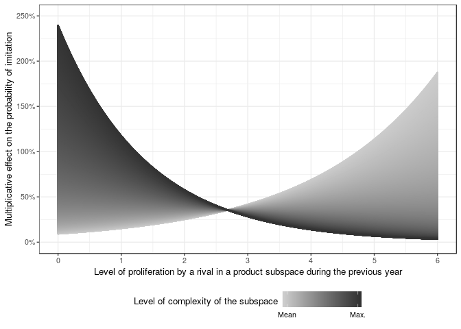

```r
marginsplot
```